# Sarcastic Comments on Reddit - An Analysis

## Sarcastic and Ironic Comments on Reddit - Sentiment Analysis

#### By: Nour Mansour and Juan Estrella

### Introduction

Sentiment analysis provides [useful information](https://www.reputation.com/resources/blog/5-real-world-sentiment-analysis-use-cases/) to companies, government, and developers. Many businesses use sentiment analysis on their product’s online reviews to get some perspective on their customer’s likes or dislikes about the product they are providing. For example, Amazon and Yelp have online reviews to help businesses improve their products or establishments. On the other hand, government can use social media to help understand their citizens’ point of view about politicians or policies. Sentiment analysis can detect people’s real opinion from their social media comments. As for developers, teaching machines to learn and interpret language is difficult, and computer scientists are researching sarcasm specifically due to machines’ difficulty classifying it.

```python
import pandas as pd
import numpy as np
import matplotlib.pyplot as plt
import sqlite3
```

### Data Collection

We used pandas to retrieve the sarcastic dataset that was stored in a .csv file, and sqlite3 for the irony database. [Sarcastic dataset](https://www.kaggle.com/sherinclaudia/sarcastic-comments-on-reddit) & [Irony database](https://github.com/bwallace/ACL-2014-irony)

```python
# Data is saved in the same folder as the project. Then read data from tsv file
sarcasm_data = pd.read_csv("train-balanced-sarcasm.csv")

# This is the database file name
sqlite_file = 'ironate.db'

# Create the connection and cursor
conn = sqlite3.connect(sqlite_file)
cursor = conn.cursor()

# List the tables in the database to see which ones we're interested in
tables = pd.read_sql_query("SELECT name FROM sqlite_master WHERE type='table'", conn)
# tables

# Data from the sqlite db
irony_data = pd.read_sql_query("SELECT * FROM irony_commentsegment", conn)

# Read the table containing the labels (sarcastic vs not)
# into another dataframe

labels = pd.read_sql_query("SELECT * FROM irony_label", conn)

# Merge the two dataframes so we have the label and the comment
# in the same dataframe

irony_data = pd.merge(left=irony_data,right=labels, left_on='id', right_on='id')
irony_data.drop(['segment_id', 'comment_id_y', 'labeler_id', 'confidence',
             'time_given', 'viewed_thread', 'viewed_page', 'forced_decision',
             'comment_id_x', 'segment_index'], inplace = True, axis = 1)

# irony_data.head()
```

### Data Processing

Datasets

What’s in the dataset? The first dataset we found is in a .csv file which contains the sarcastic comments on reddit as mentioned earlier. This dataset contains 10 columns: label, comment, author, subreddit, score, ups, downs, date, created_utc, and parent_comment. In this project, we will be focusing on the label, comment, and parent_comment columns. The label column contains 0 as non-sarcastic and 1 as sarcastic. The comment column shows the sarcastic or non-sarcastic comments that this project will mainly focus on. Lastly, the parent_comment column provides the text of which the sarcastic or non-sarcastic comments are replying toward. The second dataset is a database which contains three tables: irony_comment, irony_commentsegment, and label. We used SQL to obtain the data and merged the irony_commentsegments and label tables using their unique identifier columns called “id”. The columns we used for this dataset are the id, text, and label. The text column shows the ironic or unironic comments on reddit. The label column describes the text column with -1, 0, 1 to show unironic, unsure, and ironic, respectively.

In the irony dataset, we dropped the rows with label 0 because these rows are neither ironic or unironic.

```python
# Reset the indices after rows with NA values are dropped
sarcasm_data.dropna(inplace=True)
sarcasm_data.drop(['author', 'score', 'ups', 'downs', 'date', 'created_utc', 'subreddit'], axis = 1, inplace = True)
sarcasm_data.reset_index(inplace = True)
sarcasm_data.drop(['index'], axis = 1, inplace = True)
# print(data.head())

# Same process for the database dataset
irony_data.dropna(inplace=True)
irony_data.reset_index(inplace = True)
irony_data.drop(['index'], axis = 1, inplace = True)
# label == 0 means "i don't know" so we dropped those to have
# two clear categories
irony_data.drop(irony_data[irony_data.label == 0].index, inplace=True)
# print(irony_data.shape)
# irony_data.head()
```

```python
sarcasm_data.groupby('label').describe()
```

| label | comment count | comment unique | comment top | comment freq | parent_comment count | parent_comment unique | parent_comment top | parent_comment freq |
| --- | --- | --- | --- | --- | --- | --- | --- | --- |
| 0 | 505405 | 479850 | Yes | 406 | 505405 | 495453 | me irl | 228 |
| 1 | 505368 | 486357 | You forgot the | 1451 | 505368 | 495295 | Why? | 148 |

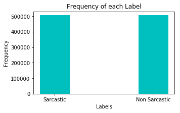

```python
# Explore distribution of the data by label (0 -> non-sarcastic, 1 -> sarcastic)
# data to plot
values = [sarcasm_data.groupby('label').agg('count').comment[1],
          sarcasm_data.groupby('label').agg('count').comment[0]]
labels = ['Sarcastic', 'Non Sarcastic']

label_pos = [i for i, _ in enumerate(labels)]

# create plot
fig, ax = plt.subplots(figsize=(5, 3))
plt.bar(label_pos, values, color = 'c', width=0.3)
plt.xlabel('Labels')
plt.ylabel('Frequency')
plt.title('Frequency of each Label')
plt.xticks(label_pos, labels)

plt.show()
```

```python
irony_data.groupby('label').describe()
```

| label | id count | id mean | id std | id min | id 25% | id 50% | id 75% | id max |
| --- | --- | --- | --- | --- | --- | --- | --- | --- |
| -1 | 26186.0 | 14419.248453 | 8344.231889 | 1.0 | 7187.25 | 14483.5 | 21691.75 | 28759.0 |
| 1 | 2573.0 | 13980.559658 | 7851.490657 | 21.0 | 7229.00 | 13401.0 | 19976.00 | 28757.0 |

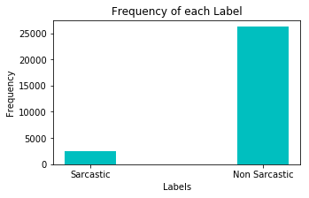

```python
# Explore distribution of the data by label (-1 -> non-sarcastic, 1 -> sarcastic)
# data to plot
values = [irony_data.groupby('label').agg('count').id[1],
          irony_data.groupby('label').agg('count').id[-1]]
labels = ['Sarcastic', 'Non Sarcastic']

label_pos = [i for i, _ in enumerate(labels)]

# create plot
fig, ax = plt.subplots(figsize=(5, 3))
plt.bar(label_pos, values, color = 'c', width=0.3)
plt.xlabel('Labels')
plt.ylabel('Frequency')
plt.title('Frequency of each Label')
plt.xticks(label_pos, labels)

plt.show()
```

In the sarcastic dataset, we dropped these comments because they do not contribute to detecting if a comment is sarcastic or not. In our assumption, these comments suggest that their parent comment is sarcastic.

```python
sarcasm_data.drop(sarcasm_data[sarcasm_data.comment =='You forgot the'].index, inplace=True)
sarcasm_data.drop(sarcasm_data[sarcasm_data.comment =='you forgot the'].index, inplace=True)
sarcasm_data.drop(sarcasm_data[sarcasm_data.comment =='you dropped this:'].index, inplace=True)
sarcasm_data.drop(sarcasm_data[sarcasm_data.comment =='You dropped this:'].index, inplace=True)
sarcasm_data.drop(sarcasm_data[sarcasm_data.comment =='Forgot the'].index, inplace=True)
sarcasm_data.drop(sarcasm_data[sarcasm_data.comment =='You forgot'].index, inplace=True)
sarcasm_data.drop(sarcasm_data[sarcasm_data.comment =='You forgot your'].index, inplace=True)
sarcasm_data.drop(sarcasm_data[sarcasm_data.comment =='You dropped this'].index, inplace=True)
sarcasm_data.drop(sarcasm_data[sarcasm_data.comment =='I think you forgot the'].index, inplace=True)
sarcasm_data.drop(sarcasm_data[sarcasm_data.comment =='You forgot this:'].index, inplace=True)
sarcasm_data.drop(sarcasm_data[sarcasm_data.comment =='You dropped your'].index, inplace=True)
sarcasm_data.drop(sarcasm_data[sarcasm_data.comment =='I forgot the'].index, inplace=True)
sarcasm_data.drop(sarcasm_data[sarcasm_data.comment =='you forgot'].index, inplace=True)
```

##### Distribution of the datasets between sarcastic and non-sarcastic comments

This graph shows the amount of data we will be using for the sarcastic dataset which is evenly split, 5033 each, between sarcastic and non-sarcastic comments. We were able to retrieve this amount of data from the original data set by using the np.random.choice to randomly choose the data we want. The size of the data for both the sarcastic and non sarcastic data was defined as ((the length of the original data set)*0.5 / 100). Finally, we used the groupby(‘label’) function to choose equal numbers of sarcastic and non-sarcastic comments.

```python
# Determine size and replacement values
size = int(len(sarcasm_data)*0.5/100)# sample size
replace = True  # with replacement
# Function used to pick random rows from the dataset
# We used the groupby('label') function to choose equal numbers
# of sarcastic and non-sarcastic comments
fun = lambda obj: obj.loc[np.random.choice(obj.index, size, replace),:]
sarcasm_prep_data = sarcasm_data.groupby('label', as_index=False).apply(fun)
# sarcasm_prep_data.head()

# Select equal number of sarcastic and non-sarcastic comments
# Determine size and replacement values
size = 2573# sample size of each group being selected
replace = True  # with replacement
irony_data = irony_data.groupby('label', as_index=False).apply(fun)
# irony_data.head()

# CSV file: Reset the indexes to remove the grouping into 0s and 1s
sarcasm_prep_data.reset_index(inplace = True)
# Delete the columns that include the names of the indexes created from the groups
sarcasm_prep_data.drop(['level_0', 'level_1'], inplace = True, axis = 1)
sarcasm_prep_data.head()
```

|  | label | comment | parent_comment |
| --- | --- | --- | --- |
| 0 | 0 | are you sure? | Guess I called it right, from the jump. #sensi... |
| 1 | 0 | The new weapons have the "reforge ready" perk ... | Can you point me to where this was confirmed? ... |
| 2 | 0 | Stefan Molyneux should read more texts aloud. | Looking for some clarity on the George Zimmerm... |
| 3 | 0 | $36,000+ | Bunch of TitanX' at gamescom ;) |
| 4 | 0 | More like little to no research by the report. | "little to no blood spatter in his home"?? try... |

```python
# DB data: Reset the indexes to remove the grouping into -1s and 1s
irony_data.reset_index(inplace = True)
# Delete the columns that include the names of the indexes created from the groups
irony_data.drop(['level_0', 'level_1'], inplace = True, axis = 1)
irony_data.head()
```

|  | id | text | label |
| --- | --- | --- | --- |
| 0 | 23135 | Let's assume that the way this man interprets... | -1 |
| 1 | 1902 | \n\nAnd, 20% of the population eats it right up. | -1 |
| 2 | 21096 | What if I want to say something horrible abo... | -1 |
| 3 | 11892 | So I can use my vagina to clean up the dog hai... | -1 |
| 4 | 19596 | Just a minor detail. | -1 |

Part 3: Exploratory Analysis & Data Visualization

```python
sarcasm_data.groupby('label').describe()
```

| label | comment count | comment unique | comment top | comment freq | parent_comment count | parent_comment unique | parent_comment top | parent_comment freq |
| --- | --- | --- | --- | --- | --- | --- | --- | --- |
| 0 | 505405 | 479850 | Yes | 406 | 505405 | 495453 | me irl | 228 |
| 1 | 501218 | 486344 | Who? | 149 | 501218 | 491218 | Why? | 147 |

```python
irony_data.groupby('label').describe()
```

| label | id count | id mean | id std | id min | id 25% | id 50% | id 75% | id max |
| --- | --- | --- | --- | --- | --- | --- | --- | --- |
| -1 | 2573.0 | 14598.998057 | 8320.215163 | 9.0 | 7344.0 | 14733.0 | 21980.0 | 28753.0 |
| 1 | 2573.0 | 14054.640109 | 7789.884662 | 21.0 | 7341.0 | 13457.0 | 19996.0 | 28757.0 |

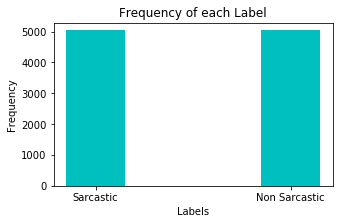

```python
# Explore distribution of the data by label (0 -> non-sarcastic, 1 -> sarcastic)
# data to plot
values = [sarcasm_prep_data.groupby('label').agg('count').comment[1],
          sarcasm_prep_data.groupby('label').agg('count').comment[0]]
labels = ['Sarcastic', 'Non Sarcastic']

label_pos = [i for i, _ in enumerate(labels)]

# create plot
fig, ax = plt.subplots(figsize=(5, 3))
plt.bar(label_pos, values, color = 'c', width=0.3)
plt.xlabel('Labels')
plt.ylabel('Frequency')
plt.title('Frequency of each Label')
plt.xticks(label_pos, labels)

plt.show()
```

##### Distribution of the datasets between ironic and unironic comments

For the irony dataset, we specifically chose 2573 to be the size for both the ironic and unironic comments because in the original database the maximum amount of ironic comments it has is 2573. Similarly to the sarcastic dataset, we used groupby(‘label’) to retrieve an even amount of ironic and unironic comments.

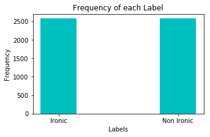

```python
# Explore distribution of the data by label (-1 -> non-sarcastic, 1 -> sarcastic)
# data to plot
values = [irony_data.groupby('label').agg('count').id[1],
          irony_data.groupby('label').agg('count').id[-1]]
labels = ['Ironic', 'Non Ironic']

label_pos = [i for i, _ in enumerate(labels)]

# create plot
fig, ax = plt.subplots(figsize=(5, 3))
plt.bar(label_pos, values, color = 'c', width=0.3)
plt.xlabel('Labels')
plt.ylabel('Frequency')
plt.title('Frequency of each Label')
plt.xticks(label_pos, labels)

plt.show()
```

### Natural Language Processing

For the Natural Language Processing, we used NLTK and Textblob to analyze the comments on both datasets.

##### [NLTK](https://www.nltk.org/api/nltk.html)

```python
# Import NLTK library
# !pip install nltk
# import nltk
# nltk.download("all")
# from nltk.tokenize import word_tokenize #Split by word
# from nltk.tokenize import sent_tokenize #Split by sentence

#Make sure all the comment column is str data type
sarcasm_prep_data['comment'] = sarcasm_prep_data['comment'].astype(str)
sarcasm_prep_data['parent_comment'] = sarcasm_prep_data['parent_comment'].astype(str)
irony_data['text'] = irony_data['text'].astype(str)

# Split the comments into words
sarcasm_prep_data['tok_comment'] = sarcasm_prep_data['comment'].apply(word_tokenize)
irony_data['tok_comment'] = irony_data['text'].apply(word_tokenize)
# Apply Parts of Speech tagging on the words
sarcasm_prep_data['POS_tag'] = sarcasm_prep_data['tok_comment'].apply(nltk.pos_tag)
irony_data['POS_tag'] = irony_data['tok_comment'].apply(nltk.pos_tag)
# sarcasm_prep_data.head()

# Apply stemming on the tokenized comments to get the roots of the words
from nltk.stem.snowball import SnowballStemmer

stemmer = SnowballStemmer("english")

sarcasm_prep_data['stem'] = sarcasm_prep_data['tok_comment'].apply(lambda x: [stemmer.stem(y) for y in x])
irony_data['stem'] = irony_data['tok_comment'].apply(lambda x: [stemmer.stem(y) for y in x])

# Joining Sarcasm data
joined_tag = []
for index, row in sarcasm_prep_data.iterrows():
    joined_tag.append(' '.join([word + "_" + pos for word, pos in row['POS_tag']]))
sarcasm_prep_data['joined_POS_tag'] = joined_tag.copy()

sarcasm_prep_data['joined_stem'] = sarcasm_prep_data['stem'].apply(lambda x: ' '.join(x))

# Joining Irony data
joined_tag = []
for index, row in irony_data.iterrows():
    joined_tag.append(' '.join([word + "_" + pos for word, pos in row['POS_tag']]))
irony_data['joined_POS_tag'] = joined_tag.copy()
irony_data['joined_stem'] = irony_data['stem'].apply(lambda x: ' '.join(x))
```

##### [Textblob](https://textblob.readthedocs.io/en/dev/)

Textblob is a library in python specifically used for analyzing textual data. It has many purposes such as POS_tagging, chunking, classification, and sentiment polarity.

Parent vs child polarity:

As for our project, we used textblob to measure the polarity of each comment and its parent comment. Polarity ranges from -1 to 1, where -1 means negative statement and 1 means positive statement.

```python
# !pip install -U textblob
from textblob import TextBlob

# Polarity for comment
blob_list = []
for index, row in sarcasm_prep_data.iterrows():
    blob_list.append(TextBlob(row['comment']))
sarcasm_prep_data['textblob'] = blob_list.copy()

polarity_list = []
for index, row in sarcasm_prep_data.iterrows():
    polarity_list.append(row['textblob'].sentiment.polarity)

sarcasm_prep_data['polarity'] = polarity_list.copy()

# Polarity for parent comment
parent_blob_list = []
for index, row in sarcasm_prep_data.iterrows():
    parent_blob_list.append(TextBlob(row['parent_comment']))
sarcasm_prep_data['parent_textblob'] = parent_blob_list.copy()

parent_polarity_list = []
for index, row in sarcasm_prep_data.iterrows():
    parent_polarity_list.append(row['parent_textblob'].sentiment.polarity)

sarcasm_prep_data['parent_polarity'] = parent_polarity_list.copy()

# Polarity for comment in Irony data
blob_list = []
for index, row in irony_data.iterrows():
    blob_list.append(TextBlob(row['text']))
irony_data['textblob'] = blob_list.copy()

polarity_list = []
for index, row in irony_data.iterrows():
    polarity_list.append(row['textblob'].sentiment.polarity)

irony_data['polarity'] = polarity_list.copy()
```

#### Comment vs Parent Comment Polarity

This graph consists of both the sarcastic or non-sarcastic comment polarity and their parent comment polarity. The x-axis is the comment polarity and the y-axis is the parent comment polarity. The blue dots represent the sarcastic comments while the red dots represent non-sarcastic comments. We used a scatter plot to show the pattern of both polarities in the graph. We wanted to find some kind of relationship pattern between a comment’s polarity and that of its parent comment polarity. The results show that there was not a clear pattern between the two but we wanted to include both in our analysis to explore it further.

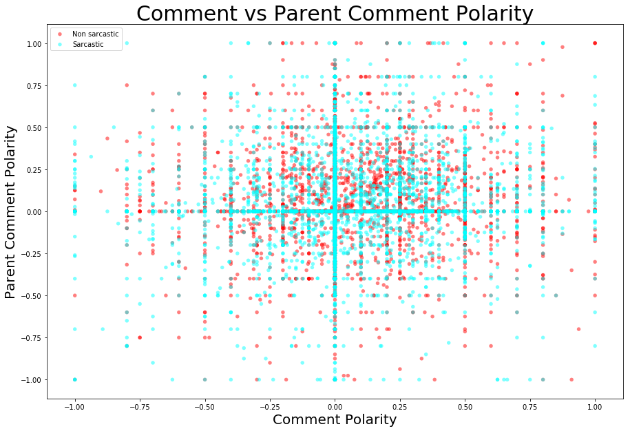

```python
# Plotting parent comment polarity vs child comment polarity
g1 = (sarcasm_prep_data.groupby('label').get_group(0)['polarity'],
     sarcasm_prep_data.groupby('label').get_group(0)['parent_polarity'])

g2 = (sarcasm_prep_data.groupby('label').get_group(1)['polarity'],
     sarcasm_prep_data.groupby('label').get_group(1)['parent_polarity'])

data = (g1, g2)
colors = ("red", "cyan")
groups = ('Non sarcastic', 'Sarcastic')

fig = plt.figure(figsize = (15, 10))
ax = fig.add_subplot(111)

for data, color, group in zip(data, colors, groups):
    x, y = data
    ax.scatter(x, y, alpha = 0.5, c = color,
               edgecolors = 'none', s = 30, label = group)

plt.title("Comment vs Parent Comment Polarity", fontsize = 30)
plt.xlabel("Comment Polarity", fontsize = 20)
plt.ylabel("Parent Comment Polarity", fontsize = 20)
plt.legend(loc = 2)
plt.show()
```

### Feature and Method Selection

We were interested in trying different models for predicting a sarcastic comment. To determine the features and labels for the analysis, we decided to look at the comment itself as a feature and use the given sarcastic vs non-sarcastic classification as our label.

Various articles and [studies](https://www.researchgate.net/publication/321738179_Sentiment_analysis_for_sarcasm_detection_on_streaming_short_text_data) looked at sarcasm and attempted to predict using different features. For instance, an [online tutorial](https://towardsdatascience.com/sarcasm-detection-step-towards-sentiment-analysis-84cb013bb6db) looked at [TF-IDF](https://scikit-learn.org/stable/modules/generated/sklearn.feature_extraction.text.TfidfVectorizer.html) as a feature, so we decided we wanted to experiment with that and see if we would get anything remotely close to their findings. Worth noting, however, that they looked at tweets with the #sarcasm tag, their dataset was significantly smaller than ours, and their training vs test data split was slightly unusual (training = 95%, test = 5%).

In addition to the stemmed comments, we chose to explore a few more features in our models. We included TF-IDF vectorization of the Parts of Speech tagged comments, comment polarity, and parent comment polarity (parent comments were only available for the sarcasm dataset). To combine these features into a feature matrix, we used the [Scipy.Sparse](https://docs.scipy.org/doc/scipy/reference/generated/scipy.sparse.hstack.html) module that allowed us to combine the sparse matrices produced from vectorization with the individual columns containing polarity.

To create a more reliable method, we decided to split our data into the more common 80-20 split for training and test subsets respectively. We also chose three main methods to compare, acknowledging that some of them might fare slightly more poorly compared to the others. We also assumed TF-IDF vectorization of the comments alone would not be a good predictor for whether a comment is sarcastic or not.

The three methods we picked were:

1. Logistic regression
2. Support Vector Machine
3. Random forest

```python
from sklearn.model_selection import train_test_split
from sklearn.svm import LinearSVC
from sklearn.linear_model import LogisticRegression
from sklearn.ensemble import RandomForestClassifier
from sklearn.linear_model import LogisticRegressionCV
```

```python
X_train, X_test, y_train, y_test = train_test_split(sarcasm_prep_data[['joined_POS_tag', 'joined_stem', 'polarity', 'parent_polarity']] , sarcasm_prep_data.label, test_size=0.2, random_state=0)
X_train.head()
```

|  | joined_POS_tag | joined_stem | polarity | parent_polarity |
| --- | --- | --- | --- | --- |
| 787 | TIL_NNP there_EX 's_VBZ a_DT sobriety_NN scene... | til there 's a sobrieti scene . | 0.0 | 0.128125 |
| 4007 | As_IN someone_NN who_WP has_VBZ supported_VBN ... | as someon who has support printer for year , i... | -0.7 | 0.000000 |
| 3188 | Lol_NNP I_PRP 've_VBP been_VBN here_RB ever_RB... | lol i ve been here ever sinc you made that com... | 0.8 | -0.100000 |
| 4763 | Lol_NN | lol | 0.8 | 0.000000 |
| 8120 | Another_DT death_NN caused_VBN by_IN alcohol_N... | anoth death caus by alcohol ? | 0.0 | 0.500000 |

```python
# For the database
db_X_train, db_X_test, db_y_train, db_y_test = train_test_split(irony_data[['joined_POS_tag', 'joined_stem', 'polarity']] , irony_data.label, test_size=0.2, random_state=0)
db_X_train.head()
```

|  | joined_POS_tag | joined_stem | polarity |
| --- | --- | --- | --- |
| 1936 | U_NNP ._. | u . | 0.000 |
| 2509 | She_PRP 's_VBZ a_DT commie_NN self_NN absorb_J... | she 's a commi self absorb corpor vultur . | 0.000 |
| 872 | He_PRP scheduled_VBD me_PRP for_IN surgery_NN ... | he schedul me for surgeri to reset ( read : re... | 0.000 |
| 831 | This_DT guy_NN defended_VBD himself_PRP as_RB ... | this guy defend himself as well as anyon could... | 0.250 |
| 1813 | The_DT problem_NN with_IN comparing_VBG it_PRP... | the problem with compar it with fb or googl is... | -0.075 |

```python
# TF-IDF to vectorize the data
import scipy.sparse as sp
from sklearn.feature_extraction.text import TfidfVectorizer

# Vectorize the stemmed comments
# Set ngram range to (1, 3) to capture longer combinations of words
stem_vectorizer = TfidfVectorizer(ngram_range = (1,3))
tfidf_stem = stem_vectorizer.fit_transform(X_train.joined_stem)

# Vectorize POS tagged comments
pos_vectorizer = TfidfVectorizer(ngram_range = (1,3))
tfidf_pos = pos_vectorizer.fit_transform(X_train.joined_POS_tag)

# Combine the first 2 features x1 = tfidf(stemmed) and x2 = tfidf(POS tagged)
combined_2 = sp.hstack([tfidf_stem, tfidf_pos], format = 'csr')
# Combine previous 2 features with x3 = comment polarity
combined_3 = sp.hstack((combined_2,np.array(X_train.polarity)[:,None]))
# Combine previous 2 features with x3 = parent polarity
combined_3_parent = sp.hstack((combined_2, np.array(X_train.parent_polarity)[:,None]))
# Combine previous 3 features with x4 = parent comment polarity
combined_4 = sp.hstack((combined_3,np.array(X_train.parent_polarity)[:,None]))

# Same process follow for the test data
test_tfidf_stem = stem_vectorizer.transform(X_test.joined_stem)
test_tfidf_pos = pos_vectorizer.transform(X_test.joined_POS_tag)

# x1 = tfidf(stemmed) and x2 = tfidf(POS tagged)
test_combined_2 = sp.hstack([test_tfidf_stem, test_tfidf_pos], format = 'csr')
# previous 2 with x3 = comment polarity
test_combined_3 = sp.hstack((test_combined_2,np.array(X_test.polarity)[:,None]))
# Combine previous 2 features with x3 = parent polarity
test_combined_3_parent = sp.hstack((test_combined_2, np.array(X_test.parent_polarity)[:,None]))
# previous 3 with x4 = parent comment polarity
test_combined_4 = sp.hstack((test_combined_3,np.array(X_test.parent_polarity)[:,None]))

# Vectorizing the data for the database dataset
# Vectorized stemmed comment
db_stem_vectorizer = TfidfVectorizer(ngram_range = (1,3)) # ask about max features
db_tfidf_stem = db_stem_vectorizer.fit_transform(db_X_train.joined_stem)

# Vectorized Parts of Speech tagged comments
db_pos_vectorizer = TfidfVectorizer(ngram_range = (1,3))
db_tfidf_pos = db_pos_vectorizer.fit_transform(db_X_train.joined_POS_tag)

# Combining the 2 features into 1 matrix x1 = tfidf(stemmed) and x2 = tfidf(POS tagged)
db_combined_2 = sp.hstack([db_tfidf_stem, db_tfidf_pos], format = 'csr')

# Combining the 3 features into 1 matrix x1 = tfidf(stemmed), x2 = tfidf(POS tagged),
# and comment polarity
db_combined_3 = sp.hstack((db_combined_2,np.array(db_X_train.polarity)[:,None]))

## Test data vectorizing, Same method as for the training data

# Transforming stemmed data in the test dataset to match the dimensions of the vectorized
# training data. Allowing this to be passed into the model produced from the training data
db_test_tfidf_stem = db_stem_vectorizer.transform(db_X_test.joined_stem)

# Transforming Parts of speech tagged data to vectorized data
db_test_tfidf_pos = db_pos_vectorizer.transform(db_X_test.joined_POS_tag)

# Combining the 2 tfidf vectorized features x1 = tfidf(stemmed) and x2 = tfidf(POS tagged)
db_test_combined_2 = sp.hstack([db_test_tfidf_stem, db_test_tfidf_pos], format = 'csr')

# Combining the previous 2 features with the 3rd features x3 = comment polarity
db_test_combined_3 = sp.hstack((db_test_combined_2,np.array(db_X_test.polarity)[:,None]))
```

```python
# Trying squared features for the model
squared_tfidf_stem = sp.csr_matrix(tfidf_stem).copy()
squared_tfidf_stem.data **= 2

squared_tfidf_pos = sp.csr_matrix(tfidf_pos).copy()
squared_tfidf_pos.data **= 2

squared_polarity = np.square(X_train.polarity)
squared_parent_polarity = np.square(X_train.parent_polarity)

# Combine the first 2 features x1 = tfidf(stemmed) and x2 = tfidf(POS tagged)
squared_combined_2 = sp.hstack([squared_tfidf_stem, squared_tfidf_pos], format = 'csr')
# Combine previous 2 features with x3 = comment polarity
squared_combined_3 = sp.hstack((combined_2,np.array(squared_polarity)[:,None]))
# Combine previous 2 features with x3 = parent polarity
squared_combined_3_parent = sp.hstack((combined_2, np.array(squared_parent_polarity)[:,None]))
# Combine previous 3 features with x4 = parent comment polarity
squared_combined_4 = sp.hstack((combined_3,np.array(squared_parent_polarity)[:,None]))

# Same process follow for the test data
squared_test_tfidf_stem = sp.csr_matrix(test_tfidf_stem).copy()
squared_test_tfidf_stem.data **= 2
squared_test_tfidf_pos = sp.csr_matrix(test_tfidf_pos).copy()
squared_test_tfidf_pos.data **= 2
squared_test_polarity = np.square(X_test.polarity)
squared_test_parent_polarity = np.square(X_test.parent_polarity)

# x1 = tfidf(stemmed) and x2 = tfidf(POS tagged)
squared_test_combined_2 = sp.hstack([squared_test_tfidf_stem, squared_test_tfidf_pos], format = 'csr')
# previous 2 with x3 = comment polarity
squared_test_combined_3 = sp.hstack((squared_test_combined_2,np.array(squared_test_polarity)[:,None]))
# Combine previous 2 features with x3 = parent polarity
test_combined_3_parent = sp.hstack((test_combined_2, np.array(squared_test_parent_polarity)[:,None]))
# previous 3 with x4 = parent comment polarity
test_combined_4 = sp.hstack((test_combined_3,np.array(squared_test_parent_polarity)[:,None]))


# Trying squared features for the model
squared_db_tfidf_stem = sp.csr_matrix(db_tfidf_stem).copy()
squared_db_tfidf_stem.data **= 2

squared_db_tfidf_pos = sp.csr_matrix(db_tfidf_pos).copy()
squared_db_tfidf_pos.data **= 2

squared_db_polarity = np.square(db_X_train.polarity)

# Combine the first 2 features x1 = tfidf(stemmed) and x2 = tfidf(POS tagged)
squared_db_combined_2 = sp.hstack([squared_db_tfidf_stem, squared_db_tfidf_pos], format = 'csr')
# Combine previous 2 features with x3 = comment polarity
squared_db_combined_3 = sp.hstack((squared_db_combined_2,np.array(squared_db_polarity)[:,None]))

# Same process followed for the test data
squared_db_test_tfidf_stem = sp.csr_matrix(db_test_tfidf_stem).copy()
squared_db_test_tfidf_stem.data **= 2
squared_db_test_tfidf_pos = sp.csr_matrix(db_test_tfidf_pos).copy()
squared_db_test_tfidf_pos.data **= 2
squared_db_test_polarity = np.square(db_X_test.polarity)

# x1 = tfidf(stemmed) and x2 = tfidf(POS tagged)
squared_db_test_combined_2 = sp.hstack([squared_db_test_tfidf_stem, squared_db_test_tfidf_pos], format = 'csr')
# previous 2 with x3 = comment polarity
squared_db_test_combined_3 = sp.hstack((squared_db_test_combined_2,np.array(squared_db_test_polarity)[:,None]))
```

### [Logistic Regression with Cross Validation](https://scikit-learn.org/stable/modules/generated/sklearn.linear_model.LogisticRegressionCV.html)

After specifying the features we are interested in looking at, we considered several models to explore which model would classify a comment with highest accuracy. The first method we implemented was Logistic Regression from the Scikit module. Logistic Regression is a method used to classify data with a categorical outcome. In our case, those categories would be sarcastic vs non-sarcastic.

The following equation, known as the sigmoid function, is the hypothesis function of the logistic regression.

$ h_ \theta (X) = \frac{\mathrm{1} }{\mathrm{1} + e^{- \theta^TX} } $ where $\theta\$ represents the parameters being trained by the model and x represents the features used to train the model. Based on this concept, we decided to experiment with several different combinations of the properties of the X matrix.

1. Model that uses 2 features (Stemmed comments and POS tagged comments)
2. Model that uses 3 features (Stemmed comments, POS tagged comments, and comment polarity)
3. Model that uses 3 features (Stemmed comments, POS tagged comments, and parent comment polarity)
4. Model that uses all 4 features (Stemmed comments, POS tagged comments, comment polarity, and parent comment polarity)
5. Model that uses the first 2 features (Stemmed comments and POS tagged comments) and a third features that is an interaction of the 2 latter features (Comment polarity and parent comment polarity)
6. Model that uses quadratic form of the features

#### Sarcasm Dataset

```python
# Model 1:
# Logistic regression using 2 features x1 = stemmed comments, x2 = POS tagged comments

cv_log_clf_1 = LogisticRegressionCV(cv = 10, solver='lbfgs', max_iter = 300).fit(combined_2, y_train)

# Logistic regression score
print("Model 1: Logistic regression: x1 = stemmed comments, x2 = POS")
print("Training score: ", cv_log_clf_1.score(combined_2, y_train))
print("Test score: ", cv_log_clf_1.score(test_combined_2, y_test))
```

```
Model 1: Logistic regression: x1 = stemmed comments, x2 = POS
Training score:  0.9981371087928465
Test score:  0.6573982125124131
```

```python
# Model 2:
# Logistic regression using 3 features x1 = stemmed comments, x2 = POS tagged comments,
# and x3 = comment polarity

cv_log_clf_2 = LogisticRegressionCV(cv = 10, solver='lbfgs', max_iter = 700).fit(combined_3, y_train)

# Logistic regression score
print("Model 2: Logistic regression: x1 = stemmed comments, x2 = POS, x3 = polarity")
print("Training score: ", cv_log_clf_2.score(combined_3, y_train))
print("Test score: ", cv_log_clf_2.score(test_combined_3, y_test))
```

```
Model 2: Logistic regression: x1 = stemmed comments, x2 = POS, x3 = polarity
Training score:  0.9981371087928465
Test score:  0.6573982125124131
```

```python
# Model 3:
# Logistic regression using 3 features x1 = stemmed comments, x2 = POS tagged comments,
# and x3 = parent comment polarity --> combined_3_parent and test_combined_3_parent

cv_log_clf_3 = LogisticRegressionCV(cv = 10, solver='lbfgs', max_iter = 700).fit(combined_3_parent, y_train)

# Logistic regression score
print("Model 3: Logistic regression: x1 = stemmed comments, x2 = POS, x3 = parent polarity")
print("Training score: ", cv_log_clf_3.score(combined_3_parent, y_train))
print("Test score: ", cv_log_clf_3.score(test_combined_3_parent, y_test))
```

```
Model 3: Logistic regression: x1 = stemmed comments, x2 = POS, x3 = parent polarity
Training score:  0.9977645305514158
Test score:  0.6628599801390268
```

```python
# Model using all 4 features on the sarcasm data from the csv file
cv_log_clf_4 = LogisticRegressionCV(cv = 10, solver='lbfgs', max_iter = 700).fit(combined_4, y_train)

# Logistic regression score
print("Model 4: Logistic regression: x1 = stemmed comments, x2 = POS, x3 = polarity, x4 = parent polarity")
print("Training score: ", cv_log_clf_4.score(combined_4, y_train))
print("Test score: ", cv_log_clf_4.score(test_combined_4, y_test))
```

```
Model 4: Logistic regression: x1 = stemmed comments, x2 = POS, x3 = polarity, x4 = parent polarity
Training score:  0.9977645305514158
Test score:  0.6613704071499503
```

```python
# Model 5:
# Logistic Regression with child polarity x parent polarity interaction

pol_train = np.array(X_train.polarity).reshape(-1, 1)
pol_test = np.array(X_test.polarity).reshape(-1, 1)

parent_pol_train = np.array(X_train.parent_polarity).reshape(-1, 1)
parent_pol_test = np.array(X_test.parent_polarity).reshape(-1, 1)

pol_interaction = np.multiply(pol_train, parent_pol_train)
test_pol_interaction = np.multiply(pol_test, parent_pol_test)

pol_combined_3 = sp.hstack((combined_2, pol_interaction))
test_pol_combined_3 = sp.hstack((test_combined_2, test_pol_interaction))

# Logistic Regression for CSV data using x1 = stemmed, x2 = POS,
# x3 = polarity interaction between parent and child

cv_log_clf_5 = LogisticRegressionCV(cv=5,solver='lbfgs', max_iter = 700).fit(pol_combined_3, y_train)

# Logistic regression score
print("Model 5: Logistic Regression: x1, x2, x3*x4")
print("Training score: ", cv_log_clf_5.score(pol_combined_3, y_train))
print("Test score: ", cv_log_clf_5.score(test_pol_combined_3, y_test))
```

```
Model 5: Logistic Regression: x1, x2, x3*x4
Training score:  0.9977645305514158
Test score:  0.6668321747765641
```

```python
# Model 6: Quadratic model with all 3 features
cv_log_clf_6 = LogisticRegressionCV(cv = 10, solver='lbfgs', max_iter = 700).fit(squared_combined_4, y_train)

# Logistic regression score
print("Model 6: Logistic regression: Quadratic model with all features")
print("Training score: ", cv_log_clf_6.score(squared_combined_4, y_train))
print("Test score: ", cv_log_clf_6.score(test_combined_4, y_test))
```

```
Model 6: Logistic regression: Quadratic model with all features
Training score:  0.9976403378042722
Test score:  0.6673286991062563
```

#### Irony Dataset

We also performed the analysis on the data from the database as well.

```python
# Model 1: Logistic Regression for DB data with 2 features

cv_db_log_clf_1 = LogisticRegressionCV(cv=5,solver='lbfgs', max_iter = 500).fit(db_combined_2, db_y_train)

# Logistic regression score
print("Logistic regression x1 = stemmed and x2 = POS tagged")
print("Training score: ", cv_db_log_clf_1.score(db_combined_2, db_y_train))
print("Test score: ", cv_db_log_clf_1.score(db_test_combined_2, db_y_test))
```

```
Logistic regression x1 = stemmed and x2 = POS tagged
Training score:  0.9851797862001944
Test score:  0.6951456310679611
```

```python
# Model 2: Logistic Regression for DB data with all 3 features

cv_db_log_clf_2 = LogisticRegressionCV(cv=10,solver='lbfgs', max_iter = 500).fit(db_combined_3, db_y_train)

# Logistic regression score
print("Logistic regression x1 = stemmed, x2 = POS tagged, x3 = polarity")
print("Training score: ", cv_db_log_clf_2.score(db_combined_3, db_y_train))
print("Test score: ", cv_db_log_clf_2.score(db_test_combined_3, db_y_test))
```

```
Logistic regression x1 = stemmed, x2 = POS tagged, x3 = polarity
Training score:  0.9859086491739553
Test score:  0.6951456310679611
```

```python
# Logistic Regression for DB data with quadratic model (3 features)

cv_db_log_clf_3 = LogisticRegressionCV(cv=10,solver='lbfgs', max_iter = 700).fit(squared_db_combined_3, db_y_train)

# Logistic regression score
print("Logistic regression: Quadratic model with all 3 features")
print("Training score: ", cv_db_log_clf_3.score(squared_db_combined_3, db_y_train))
print("Test score: ", cv_db_log_clf_3.score(squared_db_test_combined_3, db_y_test))
```

```
Logistic regression: Quadratic model with all 3 features
Training score:  0.9851797862001944
Test score:  0.6757281553398058
```

```python
# Logistic Regression for DB data with quadratic model, only 2 features

cv_db_log_clf_4 = LogisticRegressionCV(cv=10,solver='lbfgs', max_iter = 700).fit(squared_db_combined_2, db_y_train)

# Logistic regression score
print("Logistic regression: Quadratic model with all 3 features")
print("Training score: ", cv_db_log_clf_4.score(squared_db_combined_2, db_y_train))
print("Test score: ", cv_db_log_clf_4.score(squared_db_test_combined_2, db_y_test))
```

```
Logistic regression: Quadratic model with all 3 features
Training score:  0.9851797862001944
Test score:  0.6747572815533981
```

```python
# Squaring only the polarity

db_pol_max_X = sp.hstack((db_combined_2,np.array(squared_db_polarity)[:,None]))
db_pol_max_X_test = sp.hstack((db_test_combined_2,np.array(squared_db_test_polarity)[:,None]))

# Logistic Regression for DB data with quadratic model, only 2 features

cv_db_log_clf_5 = LogisticRegressionCV(cv=10,solver='lbfgs', max_iter = 700).fit(db_pol_max_X, db_y_train)

# Logistic regression score
print("Logistic regression: Quadratic model with all 3 features")
print("Training score: ", cv_db_log_clf_5.score(db_pol_max_X, db_y_train))
print("Test score: ", cv_db_log_clf_5.score(db_pol_max_X_test, db_y_test))
```

```
Logistic regression: Quadratic model with all 3 features
Training score:  0.9851797862001944
Test score:  0.6932038834951456
```

#### Results of the Logistic Regression

Based on the results above, cross-validation did not seem to help with bridging the gap between the training and test accuracy scores. In addition, it seems like the stemmed comments and parts of speech tagged comments carried most of the weight in the predictions. This is something that we would like to explore further in a future project. Specifically, we think that this analysis would benefit from exploring more methods of [feature selection](https://scikit-learn.org/stable/modules/feature_selection.html). However, this is beyond the scope of this tutorial.

### [Support Vector Machine (SVM)](https://scikit-learn.org/stable/modules/generated/sklearn.svm.LinearSVC.html)

The second method we were interested in exploring was the Support Vector Machine (SVM). We expected this method to perform more accurately compared to logistic regression. We tried the same different models using this method to see which one would perform best. For this method, we implemented the LinearSVC module from scikit-learn.

#### Sarcasm dataset:

```python
# SVM Model 1:

svm_clf_1 = LinearSVC()

# Training the model
svm_clf_1.fit(combined_2, y_train)

print("SVM with 2 features: x1 = stemmed, x2 = POS tagged")
print("Training score: ", svm_clf_1.score(combined_2, y_train))
print("Test score: ", svm_clf_1.score(test_combined_2, y_test))

# Model 2:

svm_clf_2 = LinearSVC()

# Training the model
svm_clf_2.fit(combined_3, y_train)

print("SVM with 3 features: x1 = stemmed, x2 = POS tagged, x3 = polarity")
print("Training score: ", svm_clf_2.score(combined_3, y_train))
print("Test score: ", svm_clf_2.score(test_combined_3, y_test))

# Model 3:

svm_clf_3 = LinearSVC()

# Training the model
svm_clf_3.fit(combined_3_parent, y_train)

print("SVM with 3 features: x1 = stemmed, x2 = POS tagged, x3 = parent polarity")
print("Training score: ", svm_clf_3.score(combined_3_parent, y_train))
print("Test score: ", svm_clf_3.score(test_combined_3_parent, y_test))

# Model 4:
svm_clf_4 = LinearSVC()

# Training the model
svm_clf_4.fit(combined_4, y_train)

print("SVM with 4 features: x1 = stemmed, x2 = POS tagged, x3 = polarity, x4 = parent polarity")
print("Training score: ", svm_clf_4.score(combined_4, y_train))
print("Test score: ", svm_clf_4.score(test_combined_4, y_test))

# Model 5:
svm_clf_5 = LinearSVC()

# Training the model
svm_clf_5.fit(pol_combined_3, y_train)

print("SVM with 3 features: x1 = stemmed, x2 = POS tagged, x3 = polarity*parent polarity")
print("Training score: ", svm_clf_5.score(pol_combined_3, y_train))
print("Test score: ", svm_clf_5.score(test_pol_combined_3, y_test))

# Model 6: Quadratic with 2 features
svm_clf_6 = LinearSVC()

# Training the model
svm_clf_6.fit(squared_combined_2, y_train)

print("SVM with 2 features: x1^2 = stemmed, x2^2 = POS tagged")
print("Training score: ", svm_clf_6.score(squared_combined_2, y_train))
print("Test score: ", svm_clf_6.score(squared_test_combined_2, y_test))
```

```
SVM with 2 features: x1 = stemmed, x2 = POS tagged
Training score:  0.998012916045703
Test score:  0.6583912611717975
SVM with 3 features: x1 = stemmed, x2 = POS tagged, x3 = polarity
Training score:  0.998012916045703
Test score:  0.6588877855014895
SVM with 3 features: x1 = stemmed, x2 = POS tagged, x3 = parent polarity
Training score:  0.998012916045703
Test score:  0.6583912611717975
SVM with 4 features: x1 = stemmed, x2 = POS tagged, x3 = polarity, x4 = parent polarity
Training score:  0.998012916045703
Test score:  0.6578947368421053
SVM with 3 features: x1 = stemmed, x2 = POS tagged, x3 = polarity*parent polarity
Training score:  0.998012916045703
Test score:  0.6588877855014895
SVM with 2 features: x1^2 = stemmed, x2^2 = POS tagged
Training score:  0.9910581222056631
Test score:  0.6494538232373386
```

#### Irony dataset:

```python
# SVM Model 1:
svm_clf_1 = LinearSVC()

# Training the model
svm_clf_1.fit(db_combined_2, db_y_train)

print("SVM on Irony dataset with 2 features: x1 = stemmed, x2 = POS tagged")
print("Training score: ", svm_clf_1.score(db_combined_2, db_y_train))
print("Test score: ", svm_clf_1.score(db_test_combined_2, db_y_test))

# Model 2:
svm_clf_2 = LinearSVC()

# Training the model
svm_clf_2.fit(db_combined_3, db_y_train)

print("SVM on Irony dataset with 3 features: x1 = stemmed, x2 = POS tagged, x3 = polarity")
print("Training score: ", svm_clf_2.score(db_combined_3, db_y_train))
print("Test score: ", svm_clf_2.score(db_test_combined_3, db_y_test))

# Model 3:
db_svm_clf = LinearSVC()

# Training the model
db_svm_clf.fit(squared_db_combined_3, db_y_train)

print("SVM on Irony dataset with 3 quadratic features:")
print("Training score: ", db_svm_clf.score(squared_db_combined_3, db_y_train))
print("Test score: ", db_svm_clf.score(squared_db_test_combined_3, db_y_test))

# Model 4:
db_svm_clf = LinearSVC()

# Training the model
db_svm_clf.fit(squared_db_combined_2, db_y_train)

print("SVM on Irony dataset with 2 quadratic features:")
print("Training score: ", db_svm_clf.score(squared_db_combined_2, db_y_train))
print("Test score: ", db_svm_clf.score(squared_db_test_combined_2, db_y_test))
```

```
SVM on Irony dataset with 2 features: x1 = stemmed, x2 = POS tagged
Training score:  0.9851797862001944
Test score:  0.6922330097087379
SVM on Irony dataset with 3 features: x1 = stemmed, x2 = POS tagged, x3 = polarity
Training score:  0.9851797862001944
Test score:  0.6902912621359223
SVM on Irony dataset with 3 quadratic features:
Training score:  0.978377065111759
Test score:  0.670873786407767
SVM on Irony dataset with 2 quadratic features:
Training score:  0.9788629737609329
Test score:  0.670873786407767
```

#### Results of SVM

Based on these results, it seems that polarity (for both datasets) and parent polarity (for the Sarcasm dataset) did not add much accuracy over an above using the stemmed comments and Parts of Speech tagged comments alone. Despite trying different models, it was still very difficult to produce a test data accuracy that was closer to the training data.

### [Random Forest Classifier](https://scikit-learn.org/stable/modules/generated/sklearn.ensemble.RandomForestClassifier.html)

```python
# Random Forest Classifier

rf_clf = RandomForestClassifier(n_estimators = 100)

rf_clf.fit(combined_4, y_train)

print("Training score: ", rf_clf.score(combined_4, y_train))
print("Test score: ", rf_clf.score(test_combined_4, y_test))
```

```
Training score:  0.9993790362642822
Test score:  0.6469712015888779
```

```python
# Random Forest Classifier

db_rf_clf = RandomForestClassifier(n_estimators = 100)

db_rf_clf.fit(db_combined_3, db_y_train)

print("Training score: ", db_rf_clf.score(db_combined_3, db_y_train))
print("Test score: ", db_rf_clf.score(db_test_combined_3, db_y_test))
```

```
Training score:  0.9859086491739553
Test score:  0.6961165048543689
```

#### Results of the Random Forest Classifier

The results from the Random Forest classifier mimick those of the logistic regression and the SVM. It seems like throughout all the different methods and models used, there is an issue with overfitting the data to the training set. We tried to salvage this using cross validation for the logistic regression, however those attempts were unsucessful.

### Plots of Method Comparison

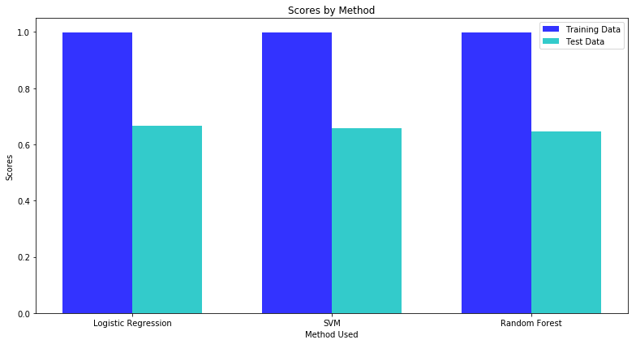

```python
# data to plot
n_groups = 3
train_score = [cv_log_clf_6.score(squared_combined_4, y_train),
          svm_clf_5.score(pol_combined_3, y_train),
          rf_clf.score(combined_4, y_train)]
test_score = [cv_log_clf_6.score(test_combined_4, y_test),
          svm_clf_5.score(test_pol_combined_3, y_test),
          rf_clf.score(test_combined_4, y_test)]

# create plot
fig, ax = plt.subplots(figsize=(11, 6))
index = np.arange(n_groups)
bar_width = 0.35
opacity = 0.8

rects1 = plt.bar(index, train_score, bar_width,
alpha=opacity,
color='b',
label='Training Data')

rects2 = plt.bar(index + bar_width, test_score, bar_width,
alpha=opacity,
color='c',
label='Test Data')

plt.xlabel('Method Used')
plt.ylabel('Scores')
plt.title('Scores by Method')
plt.xticks(index + bar_width/2, ('Logistic Regression', 'SVM', 'Random Forest'))
plt.legend()

plt.tight_layout()
plt.show()
```

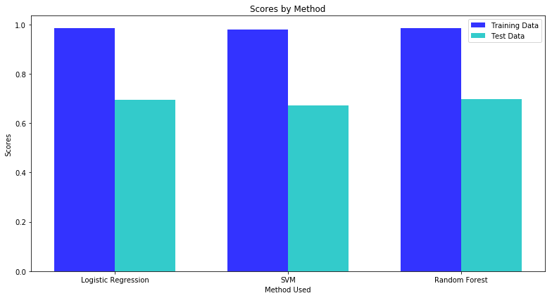

```python
# data to plot
n_groups = 3
train_score = [cv_db_log_clf_1.score(db_combined_2, db_y_train),
          db_svm_clf.score(squared_db_combined_2, db_y_train),
          db_rf_clf.score(db_combined_3, db_y_train)]
test_score = [cv_db_log_clf_1.score(db_test_combined_2, db_y_test),
          db_svm_clf.score(squared_db_test_combined_2, db_y_test),
          db_rf_clf.score(db_test_combined_3, db_y_test)]

# create plot
fig, ax = plt.subplots(figsize=(11, 6))
index = np.arange(n_groups)
bar_width = 0.35
opacity = 0.8

rects1 = plt.bar(index, train_score, bar_width,
alpha=opacity,
color='b',
label='Training Data')

rects2 = plt.bar(index + bar_width, test_score, bar_width,
alpha=opacity,
color='c',
label='Test Data')

plt.xlabel('Method Used')
plt.ylabel('Scores')
plt.title('Scores by Method')
plt.xticks(index + bar_width/2, ('Logistic Regression', 'SVM', 'Random Forest'))
plt.legend()

plt.tight_layout()
plt.show()
```

### Conclusion

Sarcasm is still very difficult to analyze using these methods

Even using different types of models like the ones we have, like the logistic regression, support vector machine, and random forest classifier, it is still difficult to predict sarcasm. The training data had high accuracy (90% range) while the test data did not (60%-70% range).

Dataset choice matters when looking at model results

Distribution of data also matters

How the data is distributed can affect outcomes.For example, we ran an analysis on the original irony database where about 90% of data belonged to one group and this gave us extremely high accuracy, just because the model was consistently predicting one group and the probability of getting that group was higher because of the size.

Future Research

Based on this exploratory analysis of sarcastic comments, we think there is still much to do with the dataset. Model performance and the use of cross-validation indicates that there are improvements to be made to this project. For instance, we think exploring the robustness of the dataset we used would be of utmost importance. Looking at whether the '/s' actually classified the comments into sarcastic vs non-sarcastic would would help the models work more accurately. In addition, we faced challenges with running the analyses on such large datasets. Our kernel would die at different stages, and as a result we were pushed to using smaller random samples of the much larger dataset. Finding a way to apply parallel processing or some other form of memory performance to the code would help us a lot. A continuation of this project would also look at the features in more detail and decide which features would be worth keeping in the model. This is something we have started researching and believe does not fit in the scope of this tutorial. In conclusion, with more knowledge of in-depth machine learning, better memory performance, and more time would definitely help to continue with this project.